# Detection of polygenic selection in genesets (polysel)

Josephine Daub

Wednesday, March 16, 2016

### Introduction

Here we describe step by step how to use the gene set enrichment pipeline, as it was applied to detect pathways that have been under positive selection in primate evolutionary history. In this case we specifically look at the **hominidae branch** of the Primates tree.

The dataset and testing procedure is described in:

Daub, J.T. et al. (2017). **Detection of pathways affected by positive selection in primate lineages ancestral to humans** Mol Biol Evol 34, 1391-1402 doi: http://doi.org/10.1093/molbev/msx083

You can find more details of the used methods in:  
Daub, J.T. et al. (2013). **Evidence for Polygenic Adaptation to Pathogens in the Human Genome.** Mol Biol Evol 30, 1544-1558 doi: http://doi.org/10.1093/molbev/mst080

All code is written in the programming language R (https://www.r-project.org/). This example is run with R version 3.3.1 (2016-06-21). Part of the code can be run on a desktop PC, but another part -especially the construction of the empirical p-value null distribution- should run on a cluster. Instructions on how to submit the code on a cluster are described below.

We advice to use the following directory structure, both on your PC and on a cluster:

- **polysel**
  - **R** - *R files with all functions needed to run the pipeline*
  - **data** - *Input text files with gene and gene set information, but also the R data object files that are created during data preparation. Each project has its own subfolder*
    - altitude
    - humanpops
    - primates
      - homininae
      - hominidae
      - hominoidae
      - catarrhini
  - **empfdr** - *Output files from the creation of the p-value null distribution (see below)*
  - **log** - *Location of error and output log files, mainly used on the cluster*
  - **script** - *Script files to run the pipeline on a cluster*
  - **results** - *Results of the gene set enrichment test, namely a list of gene sets with their scores and p and q values*

### Data preparation and inspection

In order to run the functions of the pipeline, make sure that the packages `qvalue`, `Matrix`, `igraph` are installed. You can install them with:

```r
install.packages("qvalue")
install.packages("Matrix")
install.packages("igraph")
```

Next, define the project name and set the path to input and output files:

```r
# set project variables
project.name<-"primates_hominidae"
data.path<-file.path("./data/primates/hominidae")
```

```r
# set paths
code.path<-"./R"
empfdr.path<-"./empfdr"
results.path<-"./results"
```

The file `polysel.R` contains all the functions to run the pathway enrichment pipeline.

```r
source(file.path(code.path,'polysel.R'))
```

Read in the input tables. We need three files:

1. A file with **gene set** information (here ‘SetInfo.txt’) that contains at least the fields ‘setID’ and ‘setName’.
2. A file with **gene (object)** information (here ‘ObjInfo.txt’) that contains at least the fields ‘objID’, ‘objStat’ and ‘objName’.
3. A file **linking gene sets with genes** (here ‘SetObj.txt’) that contains at least the fields ‘setID’ and ‘objID’.

Make sure that all these fields have a header, and that they are tab separated.

Here, objStat is the fourth root of the log-likelihood ratio in the branch-site test for positive selection.

We set a minimum set size to exclude too small pathways for which we usually don’t have enough power to detect signals of selection. We choose to merge similar sets (sharing more than 95% of their genes) into one ‘union set’.

```r
minsetsize<-10
result<-ReadSetObjTables(in.path=data.path,
                         set.info.file="SetInfo.txt",
                         set.obj.file="SetObj.txt",
                         obj.info.file="ObjInfo.txt",
                         minsetsize=minsetsize,
                         obj.in.set=F,
                         merge.similar.sets=T)
```

```
> Found and removed 0 gene sets in set.obj which where not in set.info
> Found and removed 1958 objects in set.obj which where not in obj.info
> Found and removed 921 gene sets in set.obj with size outside [10, 1000]
> Merged 274 sets into 93 unions of similar gene sets
```

```r
set.info<-result$set.info
obj.info<-result$obj.info
set.obj<-result$set.obj
set.info.lnk<-result$set.info.lnk

cat("Number of sets: ", nrow(set.info), "\n", sep="")
```

```
> Number of sets: 1424
```

```r
cat("Number of genes: ", nrow(obj.info), "\n", sep="")
```

```
> Number of genes: 15026
```

```r
print(set.info[1:5,],row.names=F, right=F)
```

```
 setID setName                                setSource setID.orig setSizeOrg setNameSource
 1     AMPK signaling pathway                 KEGG      989139     102        AMPK signaling pathway
 2     cGMP-PKG signaling pathway             KEGG      983748     136        cGMP-PKG signaling pathway
 3     Transcriptional activation of mitoc... REACTOME  980488      36        Transcriptional activation of mitoc...
 6     Organelle biogenesis and maintenanc... REACTOME  980485      43        Organelle biogenesis and maintenanc...
 7     negative regulation of TCF-dependen... REACTOME  980484      14        negative regulation of TCF-dependen...
```

```r
print(obj.info[1:5,],row.names=F, right=F)
```

```
 objID objStat objName chr startpos  endpos    strand treesize usedseqlength branchlength genelength objID.orig objBin
 1     0       APBB3   5   140558268 140564604 -1     5         486          0.0149         6337     10307      1
 2     0       APBB2   4    40810027  41216714 -1     7         759          0.0044       406688     323        1
 3     0       SCAP    3    47413694  47476113 -1     5        1278          0.0085        62420     22937      1
 4     0       PDPN    1    13583757  13617957  1     6         235          0.0442        34201     10630      1
 5     0       LLGL2   17   75525690  75575209  1     7        1019          0.0085        49520     3993       1
```

```r
print(set.obj[1:5,],row.names=F, right=F)
```

```
 setID objID
 2609  5176
 2609  5175
 2609  5178
 2609  5173
 2609  5177
```

With the SUMSTAT pathway enrichment test, we test if pathways (gene sets) show a shift in the distribution of their gene scores. Then the SUMSTAT score (the sum of the gene scores) is compared with a null distribution of SUMSTAT scores. The creation of such null distribution depends on several factors, they will be explained in the next paragraphs.

#### Check for bias

The gene score can be correlated to gene properties such as gene length or SNP density. For example, long genes will have on average more mutations and for this reason you will have more power to detect signals in long genes compared to small genes. If this is the case, we should correct for this in order to avoid biased test results. To investigate possible biases, you can plot the gene scores against the gene length, number of SNPs per gene or other gene properties.

In the primates dataset we investigate the correlation between gene score and total gene length, used sequence length, tree size (measured with number of branches in tree) and branch length. Note that the correlations apply to this specific dataset (hominidae), while the correlations mentioned in the Discussion section in the paper apply to all data available over all branches.

```r
flds<-c("genelength", "usedseqlength", "treesize", "branchlength")
```

```
> Correlation between objStat and genelength: p-value: 5.5e-13 estimate: -0.059 [-0.075, -0.043]
```

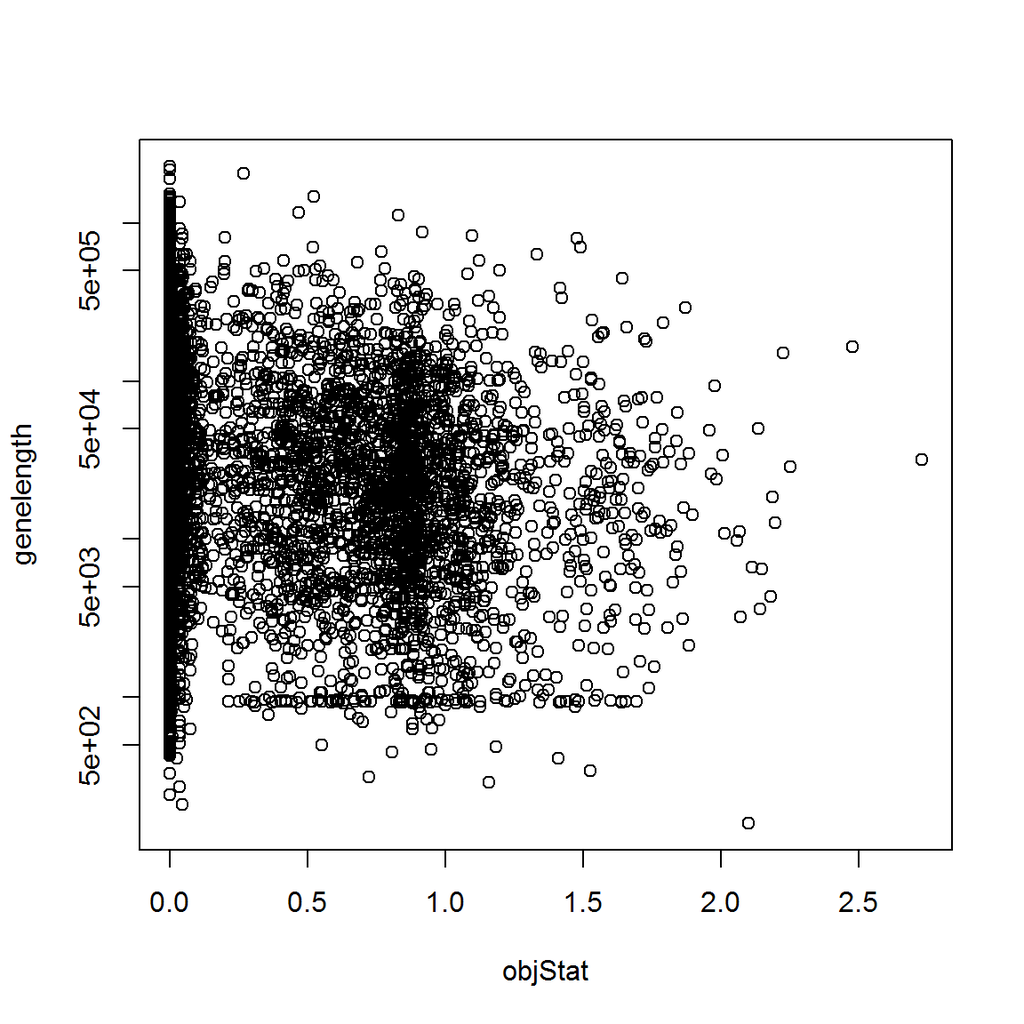

```
> Correlation between objStat and usedseqlength: p-value: 6.1e-09 estimate: -0.047 [-0.063, -0.031]
```

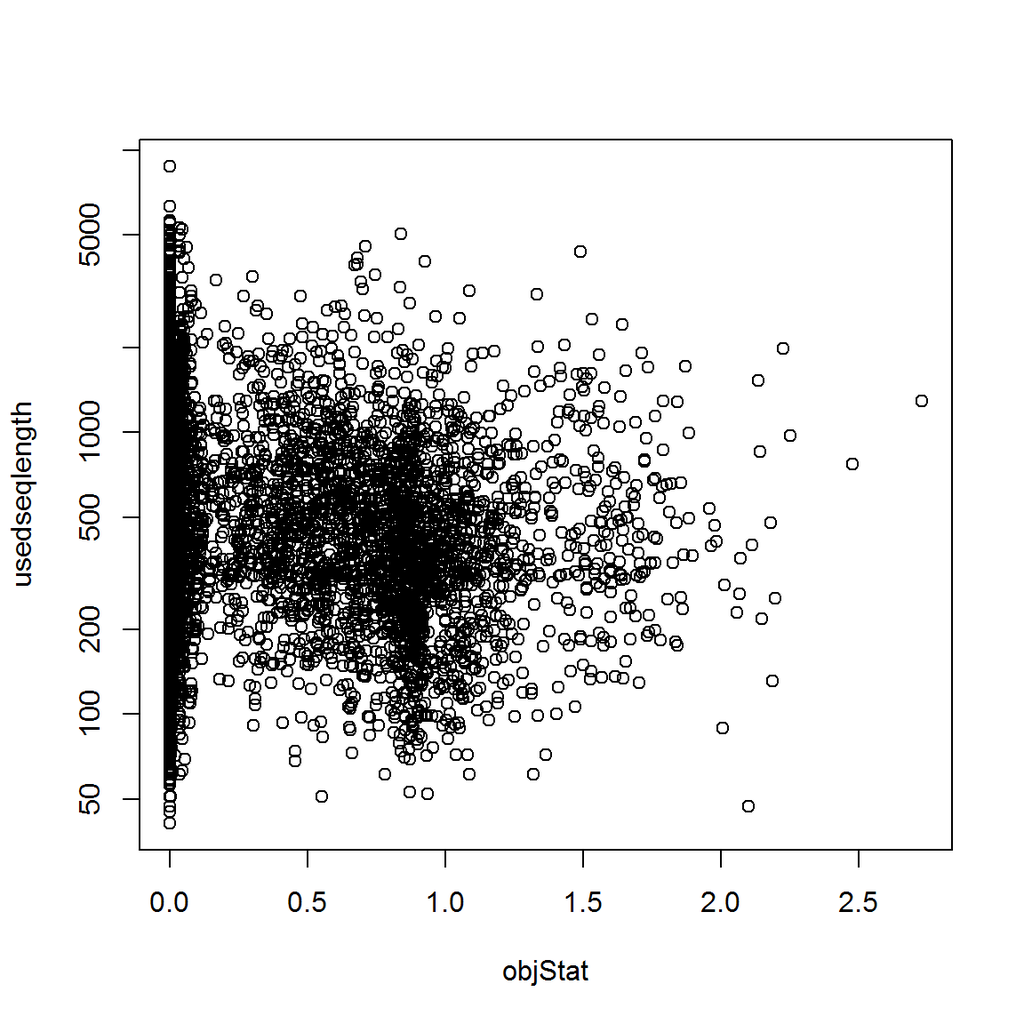

```
> Correlation between objStat and treesize: p-value: 1.2e-08 estimate: 0.046 [0.031, 0.062]
```

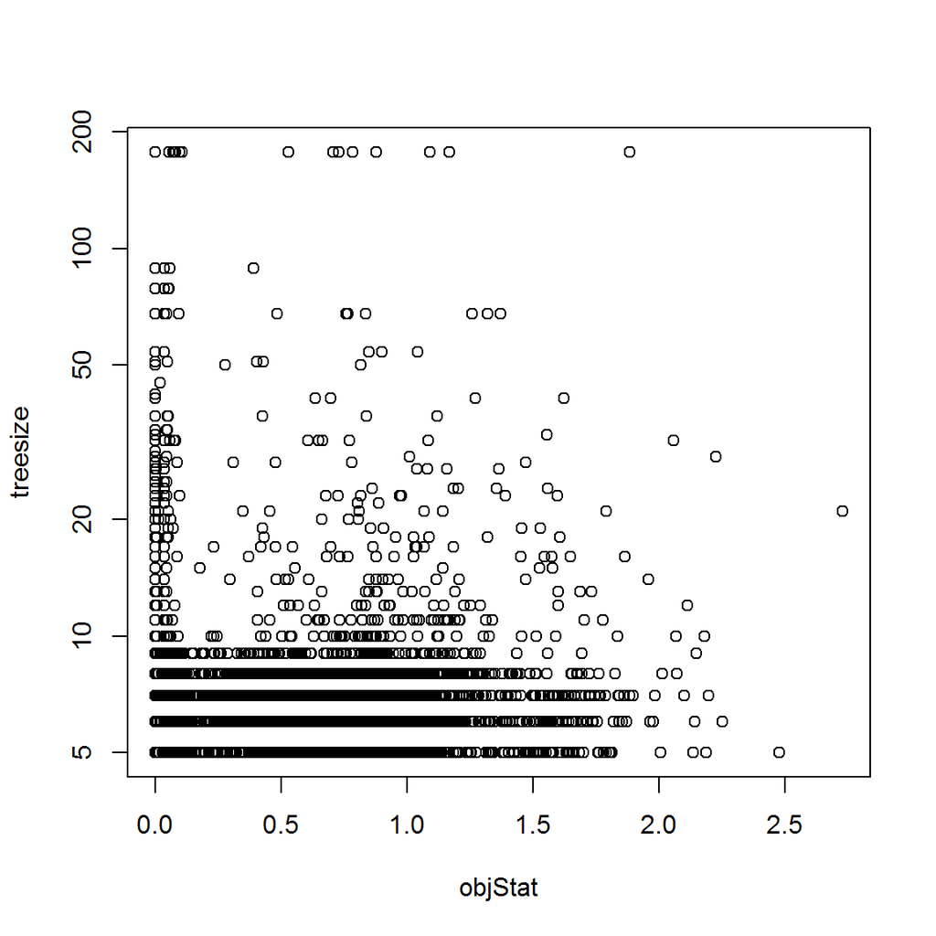

```
> Correlation between objStat and branchlength: p-value: 2.2e-118 estimate: 0.19 [0.17, 0.2]
```

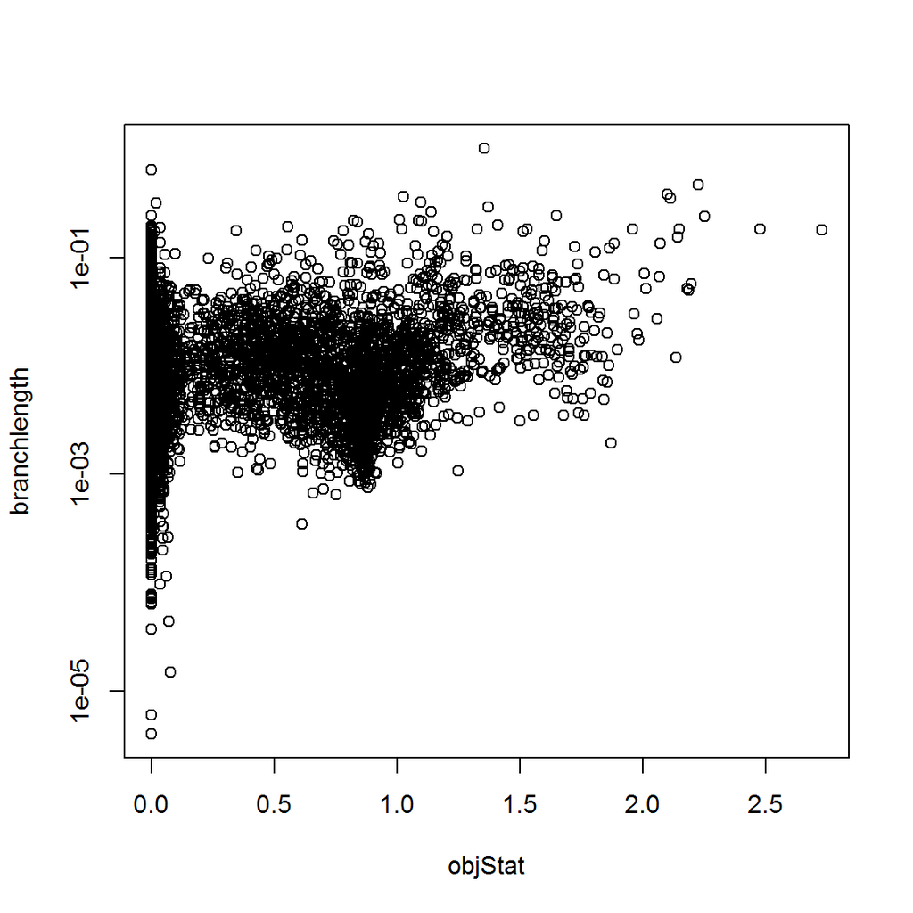

```r
options(digits=2)
for (fld in flds){
  cat("Correlation between objStat and ", fld, ": ", sep="")
  ct<-(cor.test(obj.info$objStat,obj.info[[fld]]))
  cat("p-value: ", ct$p.value, " estimate: ", ct$estimate,
      " [", ct$conf.int[1],
      ", ", ct$conf.int[2],"]\n",sep="")
  PlotStatField(obj.info, fld=fld, ylab=fld, xlab="objStat",
                logaxis="y", show.bins=F)
}
```

If there is a bias, you can correct for that by creating bins with genes that have similar values of the gene property. Then you can rescale the gene scores within each bin, or create a null distribution of random gene sets that follow the same ‘bin distribution’ as the set of interest.

Here, we find very small correlations between gene score and gene length (total length and used sequence length). We also find a larger correlation between gene score and branch length. As the branch length is inferred from the number of mutations, and since a high number of mutations can be due to a higher evolutionary rate possibly caused by positive selection (the signal that we aim to find), we decided not to correct for this correlation. See the *human populations* and *altitude projects* for examples of how you can assign genes to bins.

#### Check if gene scores are normally distributed

If you do not use bins and if sum(objStat) approximates a normal distribution, there is no need to create a null distribution. We can then use properties of all genes (namely the mean and variance of their scores), to infer the null distribution, which is much faster than creating one.

However, we can only do this if for small and large random gene sets we indeed find a Gaussian distribution of the SUMSTAT scores.

```r
for (sz in c(10,50,250)){
  CheckStatDistribution(obj.info,setsize=sz,
                        n.rand = 100000,
                        xlab="sum(objStat)")
}
```

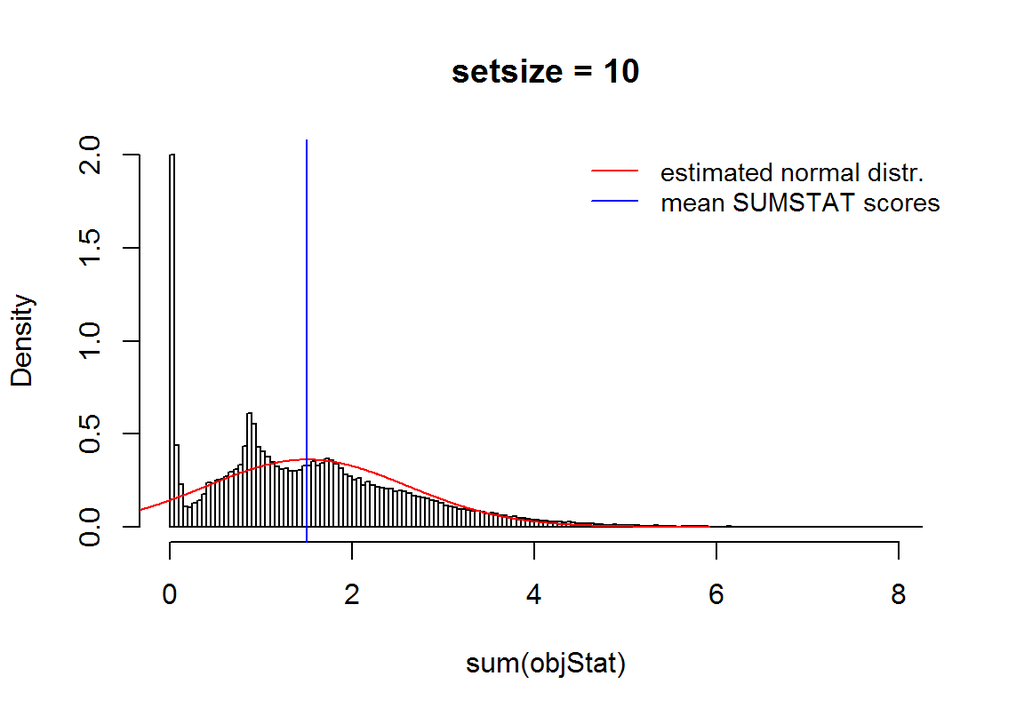

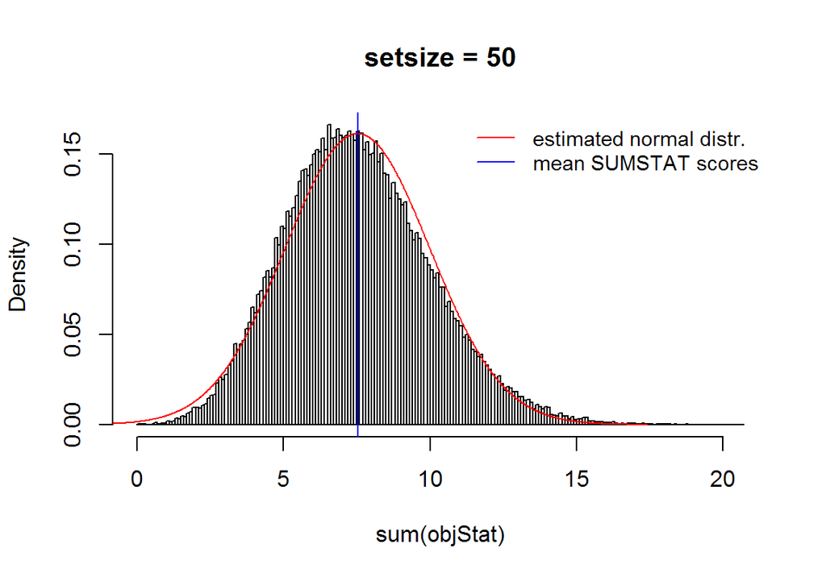

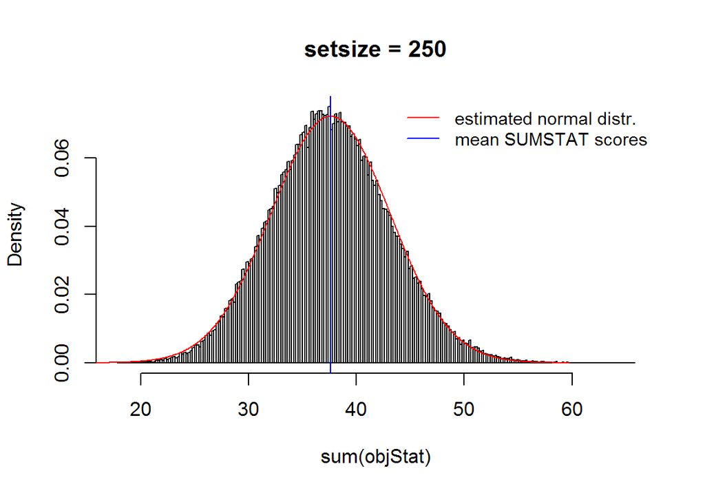

In our case we clearly see that for small sets the sum(objStat) is not normally distributed, so we will have to create a null distribution by randomly sampling genes from the list of genes. After checking for biases and checking whether the null distribution is gaussian, and -if needed- correcting `objStat` for these biases, we create the data frame `obj.stat` which is derived from `obj.info` and consists of its fields `objID`, `objStat` and `objBin`. We save all the data objects so we can use them later on for testing.

```r
obj.stat<-obj.info[,c("objID", "objStat", "objBin")]
save(set.info, obj.info, obj.stat, set.obj, set.info.lnk,
     file=file.path(data.path, "polysel_objects.RData"))
```

#### Set parameters

In our case, as we cannot approximate the SUMSTAT scores of random sets with a normal distribution, we have to create a null distribution by randomly sampling genes from the list of genes:

```r
approx.null <- FALSE
```

Furthermore, we don’t assign the genes to bins:

```r
use.bins <- FALSE
```

If we have to create a null distribution (`approx.null=FALSE`), we use a sequential random sampling method to speed up the construction of null distributions. In short, for each tested gene set, we create a small null distribution and calculate a temporary p-value. For those sets that are below a certain p-value threshold, we repeatedly increase their corresponding null distribution until a maximum number of randomizations is reached.

```r
seq.rnd.sampling <- TRUE
```

If we have to create a null distribution (`approx.null=FALSE`), we need to specify the number of random sets to create the null distribution to a sufficiently high value (> 400000 ). If you use sequential random sampling (`seq.rnd.sampling = TRUE`), you set the maximum number of randomizations. You can set to a lower value for nrand when you first want to test the function, but it should be larger than 1.

```r
nrand <- 1000
# later change to high value
```

Usually we are looking for gene sets with extremely high SUMSTAT scores, so we compare their scores to the higher tail of the null distribution.

```r
test <- "highertail"
```

Use *lowertail* or *twosided* if you are searching for low SUMSTAT scores or extreme scores respectively.

We use the function `qvalue` from the R package *qvalue* to calculate the q-value with the p-values of the tests.

We set here the parameter `pi0.method` of this function to `bootstrap`. See `?qvalue` for more information about this function.

```r
qvalue.method <- "bootstrap"
```

### Running gene set test without pruning

The enrichment pipeline will run two rounds of tests. The first round will test all gene sets and returns their p-value (and corresponding q-value). This first run usually doesn’t take a lot of time and can be done on a pc.

```r
# Test sets
result<-EnrichmentAnalysis(set.info, set.obj, obj.stat,
                    nrand=nrand, approx.null=approx.null,
                    seq.rnd.sampling=seq.rnd.sampling,
                    use.bins=use.bins, test=test,
                    do.pruning=FALSE, minsetsize=minsetsize,
                    project.txt=project.name, do.emp.fdr=FALSE,
                    qvalue.method=qvalue.method
                    )

set.scores.prepruning <- result$set.scores.prepruning
```

The ten highest scoring sets are (taking `nrand = 1000`):

```r
print(set.scores.prepruning[1:10,],row.names=F, right=F)
```

```
 setID setSize setScore setP  setQ setName                                                         setID.orig
 1256   38      12.8    0.001 0.28 Malaria                                                         152665
 1828   57      22.3    0.001 0.28 Immunoregulatory interactions between a Lymphoid and a non-L... 106413
 1855  230      69.3    0.001 0.28 Olfactory Signaling Pathway                                     106383
 2475  252      70.8    0.001 0.28 Olfactory transduction                                          83087
 2531   57      16.8    0.001 0.28 Metabolism of xenobiotics by cytochrome P450                    83031
 1095   44      14.5    0.002 0.36 Staphylococcus aureus infection                                 172846
  708   11       5.3    0.003 0.36 Bile acid biosynthesis, cholesterol => cholate/chenodeoxycho... 413432
  885   46      14.4    0.003 0.36 Oxidative phosphorylation                                       198870
 1604   40      12.7    0.003 0.36 Intestinal immune network for IgA production                    128760
 1637  672     128.4    0.003 0.36 GPCR downstream signaling                                       119548
```

Ultimately, when setting `nrand = 1000000`, the top scoring sets will be:

```
>  setID setSize setScore setP    setQ    setName                                                         setID.orig
>   990  230      69      1.0e-06 0.00071 Olfactory Signaling Pathway                                     106383
>  1306  252      71      1.0e-06 0.00071 Olfactory transduction                                          83087
>   975   57      22      2.0e-06 0.00095 Immunoregulatory interactions between a Lymphoid and a non-L... 106413
>   871  672     128      4.0e-06 0.00142 GPCR downstream signaling                                       119548
>  1003  753     137      7.0e-06 0.00199 Signaling by GPCR                                               106356
>   586   44      14      3.3e-04 0.07737 Staphylococcus aureus infection                                 172846
>   675   38      13      4.8e-04 0.08876 Malaria                                                         152665
>  1362   57      17      5.0e-04 0.08876 Metabolism of xenobiotics by cytochrome P450                    83031
>   425   46      14      5.6e-04 0.08876 Oxidative phosphorylation                                       198870
>   852   40      13      1.1e-03 0.13134 Intestinal immune network for IgA production                    128760
```

You can save the results as R data object or text file for further analysis.

```r
save(set.scores.prepruning,
     file = file.path(results.path,
            paste(project.txt=project.name,
            "_setscores_prepruning_",
            formatC(nrand,format="d"),".RData", sep="")))

write.table(set.scores.prepruning, quote=FALSE, sep="\t", row.names=FALSE,
            file = file.path(results.path, paste(project.txt=project.name,
                   "_setscores_prepruning_", formatC(nrand,format="d"),".txt",
                   sep="")))
```

### Running gene set test with pruning

In the second round the overlap is removed between gene sets in a process called *pruning*. In short, the genes from the highest scoring gene set will be removed from all lower ranked gene sets and these gene sets will be retested. This process is repeated until no large enough sets are left to be tested. This pruning step will take more time (about 30 minutes on a single pc) and will return a shorter list of pruned gene sets with their p-values.

```r
# Test sets
result<-EnrichmentAnalysis(set.info, set.obj, obj.stat,
                    nrand=nrand, approx.null=approx.null,
                    seq.rnd.sampling=seq.rnd.sampling,
                    use.bins=use.bins, test=test,
                    do.pruning=TRUE, minsetsize=minsetsize,
                    project.txt=project.name, do.emp.fdr=FALSE,
                    qvalue.method=qvalue.method
                    )

set.scores.postpruning <- result$set.scores.postpruning
```

After pruning, the ten highest scoring sets are now (taking `nrand = 1000`):

```r
print(set.scores.postpruning[1:10,],row.names=F, right=F)
```

```
 setID setSize setScore setP  setQ setName                                                         setID.orig
 1256   38      12.8    0.001 -1   Malaria                                                         152665
 1637  671     128.4    0.001 -1   GPCR downstream signaling                                       119548
 1828   49      19.5    0.001 -1   Immunoregulatory interactions between a Lymphoid and a non-L... 106413
 2531   57      16.8    0.002 -1   Metabolism of xenobiotics by cytochrome P450                    83031
  885   46      14.4    0.002 -1   Oxidative phosphorylation                                       198870
  147   47      13.8    0.004 -1   Fatty acid metabolism                                           868084
 2009   17       7.2    0.005 -1   Synthesis of bile acids and bile salts via 7alpha-hydroxycho... 106146
 1590   20       7.5    0.009 -1   TRAIL signaling pathway                                         137920
  643   34       9.9    0.010 -1   Defensins                                                       530757
   61   10       4.3    0.013 -1   Dopamine metabolism                                             920995
```

Ultimately, when setting `nrand = 1000000`, the top scoring sets after pruning will be:

```
>  setID setSize setScore setP    setQ setName                                                         setID.orig
>   990  230     69.3     1.0e-06 -1   Olfactory Signaling Pathway                                     106383
>   975   57     22.3     2.0e-06 -1   Immunoregulatory interactions between a Lymphoid and a non-L... 106413
>  1362   57     16.8     5.1e-04 -1   Metabolism of xenobiotics by cytochrome P450                    83031
>   425   46     14.4     6.2e-04 -1   Oxidative phosphorylation                                       198870
>   852   36     11.7     1.3e-03 -1   Intestinal immune network for IgA production                    128760
>    61   47     13.8     1.4e-03 -1   Fatty acid metabolism                                           868084
>  1068   17      7.2     1.6e-03 -1   Synthesis of bile acids and bile salts via 7alpha-hydroxycho... 106146
>   857   47     13.5     2.0e-03 -1   NOD-like receptor signaling pathway                             122191
>   991   30     10.0     2.2e-03 -1   Class C/3 (Metabotropic glutamate/pheromone receptors)          106381
>   839   17      6.3     5.6e-03 -1   TRAIL signaling pathway                                         137920
```

As you can see, q-values are not calculated yet, this will be done using an empirical p-value distribution. The creation of such a distribution is explained below.

### Creating p-value null distribution to infer FDR empirically

The pruning test will result in a list of p-values biased toward lower p-values. We will therefore estimate the FDR using a empirical p-value distribution. For this we will repeatedly shuffle the gene scores and retest the gene sets (including pruning). In order to calculate an empirical FDR on the p-values that are the result of the test with pruning, we need to create a null-distribution of p-values. This is done by permuting (*shuffling*) the gene scores while keeping the gene set definition as is (`set.obj`). After each permutition the gene sets are tested with pruning and the resulting p-values are stored in a file. Usually around 200-300 of such randomizations are performed. On a single desktop this could take up to 150 hours.

*This part should best be run on a cluster.*

On a cluster one could easily create and run one job per randomization reducing the computation time significantly. We provide an R script and example bash scripts to submit such jobs. Make sure which submission system your cluster is using and what is the policy to submit jobs on your cluster, as this differs per organization.

To test functionality on a single PC, one can run only a small number of randomizations.

```r
# to see if everything works fine, you can first set a low number of runs to test the function
emp.fdr.nruns <- 3
```

```r
for (r in seq(from=1, to=emp.fdr.nruns)){
# Test randomized sets
TestShuffledSets(set.info, set.obj, obj.stat,
                 nrand=nrand, minsetsize=minsetsize,
                 approx.null=approx.null, test=test,
                 seq.rnd.sampling=seq.rnd.sampling,
                 use.bins=use.bins, out.path=empfdr.path,
                 runnr=r, project.txt=project.name)
}
```

#### Creating p-value null distribution on a CLUSTER

To create the p-value null distribution on a cluster, we provide an R file `polysel_shufflesets_cluster.R` that calls the `TestShuffleSets` function with commandline arguments. This file can be found in the *./R* folder. You can then use the script `polysel_shufflesets_cluster.sh` that calls this R file (in *./script* folder).

Make sure to copy the dataset (`polysel_objects.RData`) to the corresponding data directory (in this case *./data/primates/hominidae*)

The submission of a job that calls this script depends on the type of cluster submission system you use and the submission rules that apply in your organization. Here is an example how you can submit a job that calls the `polysel_shufflesets_cluster.sh` script on a **SGE** (Sun Grid Enginge) cluster. Make sure that you call this script from the project root directory (*polysel* in our example). More examples of these commands can be found in the file `Examples_submit_on_cluster`

```bash
projectname="primates_hominidae"
for i in {1..300}
do
qsub -l h_cpu=2:00:00 -l h_vmem=4G -o ./log/shuffle${i}_${projectname}.out \
-e ./log/shuffle${i}_${projectname}.err -cwd -N shuffle${i}_${projectname} \
./script/polysel_shufflesets_cluster.sh $i $projectname
done
```

### Calculation of empirical FDR

This part can be run on your desktop. On the cluster, you would usually do the test with and without pruning together with the calculation of the empirical FDR in one go. If you run the test on your desktop and if the p-value null distribution is created on cluster, then first move the corresponding files from the *./empfdr* folder on the cluster to the same folder on your desktop (*./empfdr*).

#### Run on a desktop:

```r
# don't estimate m0, the proportion of true nulls, but take m0=1
# (conservative)
emp.fdr.est.m0<-FALSE
```

```r
set.scores.postpruning<-
  GetEmpericalFDR(set.scores=set.scores.postpruning,
                  in.path=empfdr.path,
                  nruns=emp.fdr.nruns,
                  est.m0=emp.fdr.est.m0,
                  project.txt=project.name,
                  nrand=nrand)
```

Now each gene set remaining after pruning has an empirical q-value (taking `nrand = 1000`, and `emp.fdr.nruns = 3`):

```r
print(set.scores.postpruning[1:10,],row.names=F, right=F)
```

```
 setID setSize setScore setP  setQ setName                                                         setID.orig
 1256   38      12.8    0.001 0.29 Malaria                                                         152665
 1637  671     128.4    0.001 0.29 GPCR downstream signaling                                       119548
 1828   49      19.5    0.001 0.29 Immunoregulatory interactions between a Lymphoid and a non-L... 106413
 2531   57      16.8    0.002 0.59 Metabolism of xenobiotics by cytochrome P450                    83031
  885   46      14.4    0.002 0.59 Oxidative phosphorylation                                       198870
  147   47      13.8    0.004 0.79 Fatty acid metabolism                                           868084
 2009   17       7.2    0.005 0.79 Synthesis of bile acids and bile salts via 7alpha-hydroxycho... 106146
 1590   20       7.5    0.009 1.00 TRAIL signaling pathway                                         137920
  643   34       9.9    0.010 1.00 Defensins                                                       530757
   61   10       4.3    0.013 1.00 Dopamine metabolism                                             920995
```

Ultimately, when setting `nrand = 1000000`, and `emp.fdr.nruns = 300` the empirical q-values of the top scoring sets after pruning will be:

```
>  setID setSize setScore setP    setQ setName                                                         setID.orig
>   990  230     69.3     1.0e-06 0.00 Olfactory Signaling Pathway                                     106383
>   975   57     22.3     2.0e-06 0.00 Immunoregulatory interactions between a Lymphoid and a non-L... 106413
>  1362   57     16.8     5.1e-04 0.14 Metabolism of xenobiotics by cytochrome P450                    83031
>   425   46     14.4     6.2e-04 0.14 Oxidative phosphorylation                                       198870
>   852   36     11.7     1.3e-03 0.19 Intestinal immune network for IgA production                    128760
>    61   47     13.8     1.4e-03 0.19 Fatty acid metabolism                                           868084
>  1068   17      7.2     1.6e-03 0.19 Synthesis of bile acids and bile salts via 7alpha-hydroxycho... 106146
>   857   47     13.5     2.0e-03 0.20 NOD-like receptor signaling pathway                             122191
>   991   30     10.0     2.2e-03 0.20 Class C/3 (Metabotropic glutamate/pheromone receptors)          106381
>   839   17      6.3     5.6e-03 0.39 TRAIL signaling pathway                                         137920
```

Again, you can save the results as R data object or text file.

```r
save(set.scores.postpruning,
     file = file.path(results.path,
            paste(project.txt=project.name,
            "_setscores_postpruning_",
            formatC(nrand,format="d"),".RData", sep="")))

write.table(set.scores.postpruning, quote=FALSE, sep="\t", row.names=FALSE,
            file = file.path(results.path, paste(project.txt=project.name,
                   "_setscores_postpruning_", formatC(nrand,format="d"),".txt",
                   sep="")))
```

#### Run on a cluster:

To run the complete test (with and without pruning) on a cluster, you can use the script `polysel_cluster.sh` (located in *./script* folder) that calls the R file `polysel_cluster.R` (located in *./R* folder)

Again, the submission of a job that calls this script depends on the type of cluster submission system you use and the submission rules that apply in your organization. Here is an example how you can submit a job that calls the `polysel_cluster.sh` script on a **SGE** (Sun Grid Enginge) cluster. Make sure that you call this script from the project root directory (*polysel* in our example).

```bash
projectname="primates_hominidae"
qsub -l h_cpu=5:00:00 -l h_vmem=4G -o ./log/${projectname}.out \
-e ./log/${projectname}.err -cwd -N ${projectname} \
./script/polysel_cluster.sh $projectname
```